# 본인이름_사례분석.Rmd

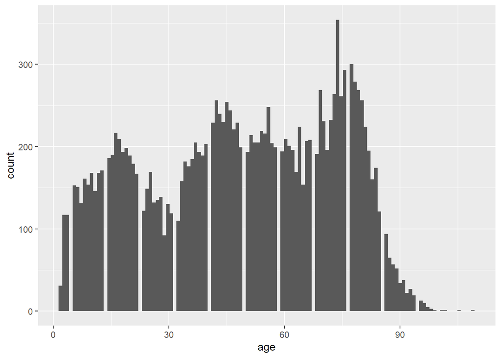

```r
ggplot(data=welfare,aes(age))+
  geom_histogram(binwidth=0.9)
```

### 3.3. x축을 나와 y축을 나이별 평균 월급의 변화로 시각화

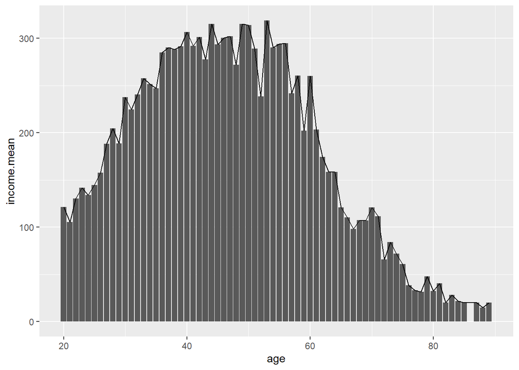

```r
age_income <- welfare %>%
  filter(!is.na(welfare$income)) %>%
  group_by(age) %>%
  summarise(income.mean = mean(income),
            income.sd = mean(income))

ggplot(age_income,aes(x=age,y=income.mean))+
  geom_bar(stat="identity")+
  geom_line()
```

### 3.4.나이에 따른 월급의 차이가 있는지 분석

```r
result<-aov(income~age,data=welfare)
summary(result)
```

```
##               Df    Sum Sq Mean Sq F value Pr(>F)
## age            1   3140845 3140845   94.42 <2e-16 ***
## Residuals   4618 153617715   33265
## ---
## Signif. codes:  0 '***' 0.001 '**' 0.01 '*' 0.05 '.' 0.1 ' ' 1
## 12044 observations deleted due to missingness
```

```r
fit<-lm(income~age,data=welfare)
anova(fit)
```

```
## Analysis of Variance Table
##
## Response: income
##             Df    Sum Sq Mean Sq F value    Pr(>F)
## age          1   3140845 3140845  94.419 < 2.2e-16 ***
## Residuals 4618 153617715   33265
## ---
## Signif. codes:  0 '***' 0.001 '**' 0.01 '*' 0.05 '.' 0.1 ' ' 1
```

### 3.5.월급을 가장 많이 받는 나이대

```r
age_income %>%
  arrange(-income.mean) %>% # 월급을 가장 많이 받는 나이:53
  head(1)
```

```
## # A tibble: 1 x 3
##     age income.mean income.sd
##   <dbl>       <dbl>     <dbl>
## 1    53        319.      319.
```

## 4. 연령대에 따른 월급 차이

### 4.1 파생변수 agegrade를 필드로 추가.

```r
welfare$agegrade<-ifelse(welfare$age<=30,'young',
                         ifelse(welfare$age<=60,'middle','old'))
```

### 4.2 agegrade 의 분포를 도표와 그래프로 시각화한다

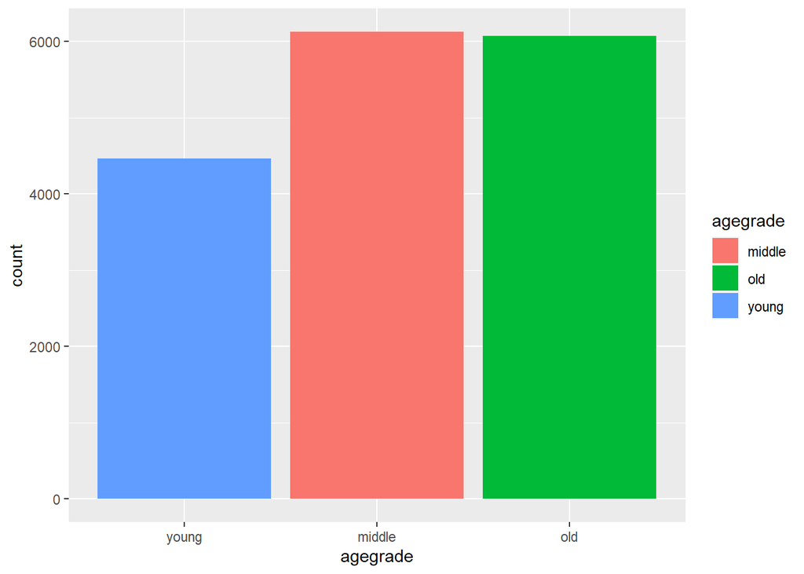

```r
ggplot(data = welfare, aes(x = agegrade))+
  geom_bar(aes(fill=agegrade))+
  scale_x_discrete(limits=c('young','middle','old')) #순서바꾸기
```

### 4.3 연령대 별 월급의 boxplot을 시각화

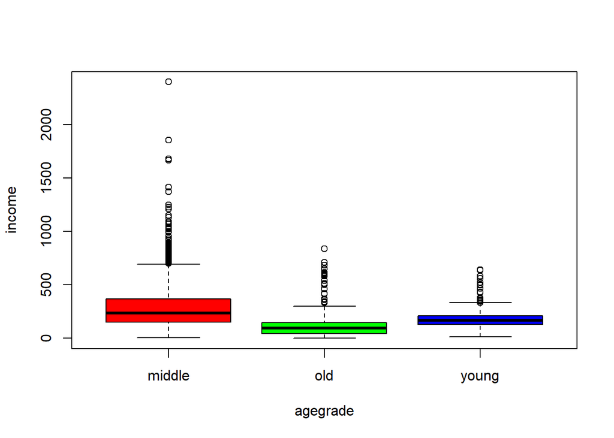

```r
boxplot(income~agegrade,data=welfare,col=c('red','green','blue'))
```

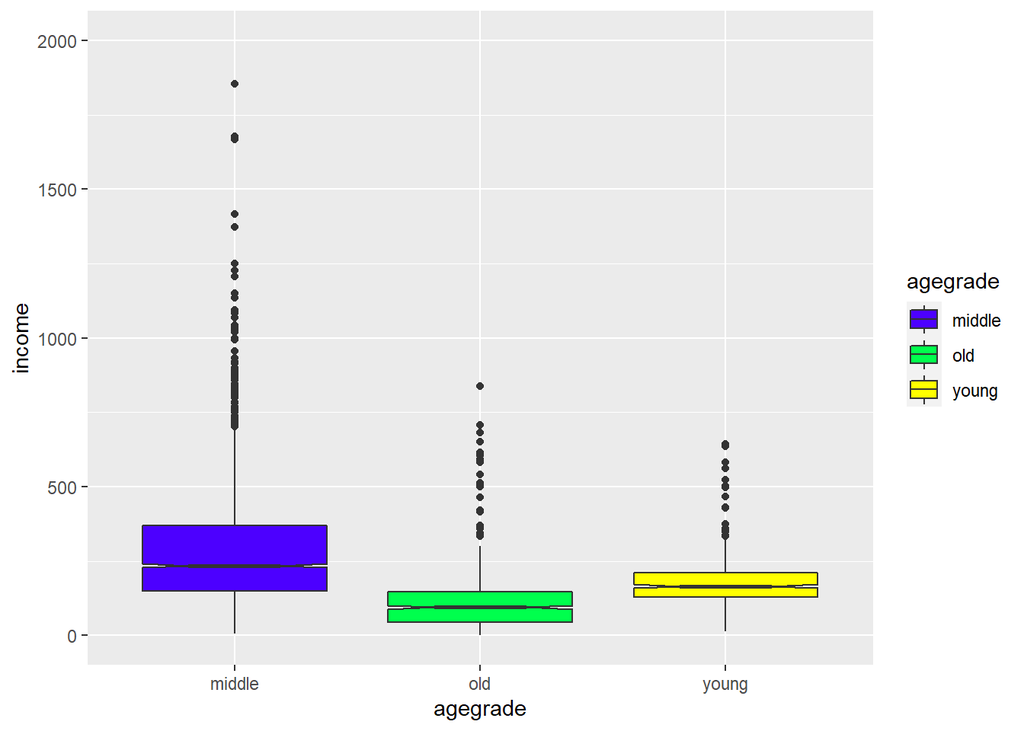

```r
ggplot(welfare,aes(x=agegrade,y=income,fill=agegrade))+
  geom_boxplot(notch=T)+
  scale_fill_manual(values=topo.colors(3))+
  coord_cartesian(ylim=c(0,2000))
```

### 4.4 연령대에 따른 월급 차이가 있는지 분석 도표

```r
agegrade_income <- welfare %>%
  group_by(agegrade) %>%
  summarise(income.mean = mean(income, na.rm=T),
            income.sd= sd(income, na.rm=T))
agegrade_income
```

```
## # A tibble: 3 x 3
##   agegrade income.mean income.sd
## * <chr>          <dbl>     <dbl>
## 1 middle          282.     194.
## 2 old             113.     103.
## 3 young           174.      86.8
```

```r
summaryBy(income~agegrade, welfare, FUN=c(mean, sd), na.rm=T)
```

```
##   agegrade income.mean income.sd
## 1   middle    282.4978 193.55518
## 2      old    113.2301 103.30605
## 3    young    173.8400  86.76442
```

### 4.5 연령대에 따른 월급 차이가 있는지 분석 시각화

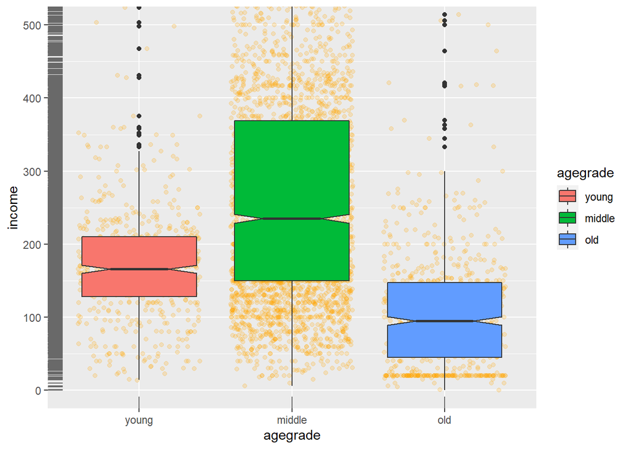

```r
ggplot(welfare,aes(x=agegrade,y=income))+
  geom_point(position='jitter',col='orange',alpha=0.2)+
  geom_boxplot(aes(fill=agegrade),notch=T)+
  scale_x_discrete(limits=c('young','middle','old'))+
  scale_fill_discrete(limits=c('young','middle','old'))+
  geom_rug(col='dimgray')+
  coord_cartesian(ylim=c(0,500))
```

### 4.6 연령대에 따른 월급 차이가 통계적으로 유의미한지 분석

```r
temp<-welfare %>% filter(!is.na(income))
result<-aov(income~agegrade,data=temp)
summary(result)
```

```
##               Df    Sum Sq  Mean Sq F value Pr(>F)
## agegrade       2  20247866 10123933   342.4 <2e-16 ***
## Residuals   4617 136510694    29567
## ---
## Signif. codes:  0 '***' 0.001 '**' 0.01 '*' 0.05 '.' 0.1 ' ' 1
```

## 5.성별에 따른 월급차이는 연령대별로 다를까?

### 5.1 결측치 확인

```r
table(is.na(welfare$gender))
```

```
##
## FALSE
## 16664
```

```r
table(is.na(welfare$agegrade))
```

```
##
## FALSE
## 16664
```

```r
table(is.na(welfare$income))
```

```
##
## FALSE  TRUE
##  4620 12044
```

### 5.2 연령대별, 성별 월급의 평균과 표준편차, 빈도를 출력

```r
library(doBy)
summaryBy(income~agegrade,data=welfare,FUN=c(mean,sd),na.rm=T)
```

```
##   agegrade income.mean income.sd
## 1   middle    282.4978 193.55518
## 2      old    113.2301 103.30605
## 3    young    173.8400  86.76442
```

```r
summaryBy(gender~agegrade,data=welfare,FUN=c(mean,sd),na.rm=T)
```

```
##   agegrade gender.mean gender.sd
## 1   middle    1.491188 0.4999631
## 2      old    1.394104 0.4886976
## 3    young    1.487231 0.4998929
```

```r
gender_agegrade_income<-welfare %>%
  filter(!is.na(income)) %>%
  group_by(agegrade,gender) %>%
  summarise(income.mean=mean(income),
            income.sd=sd(income),
            n=n())
gender_agegrade_income
```

```
## # A tibble: 6 x 5
## # Groups:   agegrade [3]
##   agegrade gender income.mean income.sd     n
##   <chr>    <fct>        <dbl>     <dbl> <int>
## 1 middle   female       186.      138.   1425
## 2 middle   male         355.      198.   1898
## 3 old      female        75.7      56.8   395
## 4 old      male         157.      126.    340
## 5 young    female       168.       82.2   348
## 6 young    male         184.       93.0   214
```

### 5.3 성별에 따른 월급의차이가 연령대별로 다른지 시각화

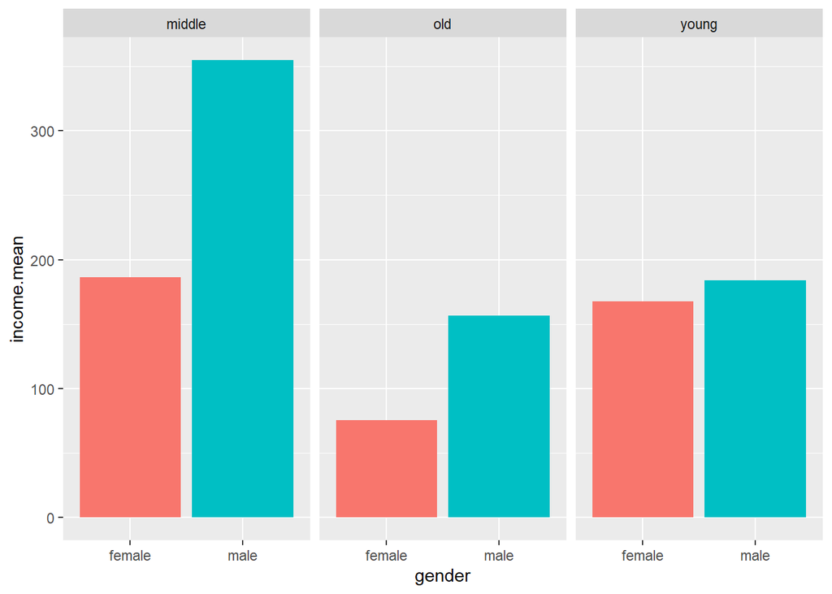

```r
ggplot(gender_agegrade_income, aes(x=gender, y=income.mean)) +
  geom_col(aes(fill=gender))+
  facet_wrap(~agegrade) +
  theme(legend.position = "none")
```

```r
gender_age_income<-welfare %>%
  filter(!is.na(welfare$income)) %>%
  group_by(age,gender) %>%
  summarise(income.mean=mean(income),
            income.sd=sd(income),
            income.median=median(income),
            income.min=min(income),
            income.max=max(income),
            n=n())
gender_age_income
```

```
## # A tibble: 134 x 8
## # Groups:   age [69]
##      age gender income.mean income.sd income.median income.min income.max     n
##    <dbl> <fct>        <dbl>     <dbl>         <dbl>      <dbl>      <dbl> <int>
##  1    20 female        147.      8.27         147.       142.        153.     2
##  2    20 male           69      NA             69         69          69      1
##  3    21 female        107.     64.0          110         22         258.    19
##  4    21 male          102.     23.4           97.5       63.6       140      8
##  5    22 female        140.     82.6          150         15         358.    17
##  6    22 male          118.     65.1          103         36.7       280     14
##  7    23 female        139.     76.1          120         40         350     19
##  8    23 male          153.     61.3          139.        96         240      4
##  9    24 female        126.     63.5          136         20         302.    40
## 10    24 male          158.     63.2          155         60         280     13
## # ... with 124 more rows
```

### 6.2나이에 따른 월급 평균의 추이

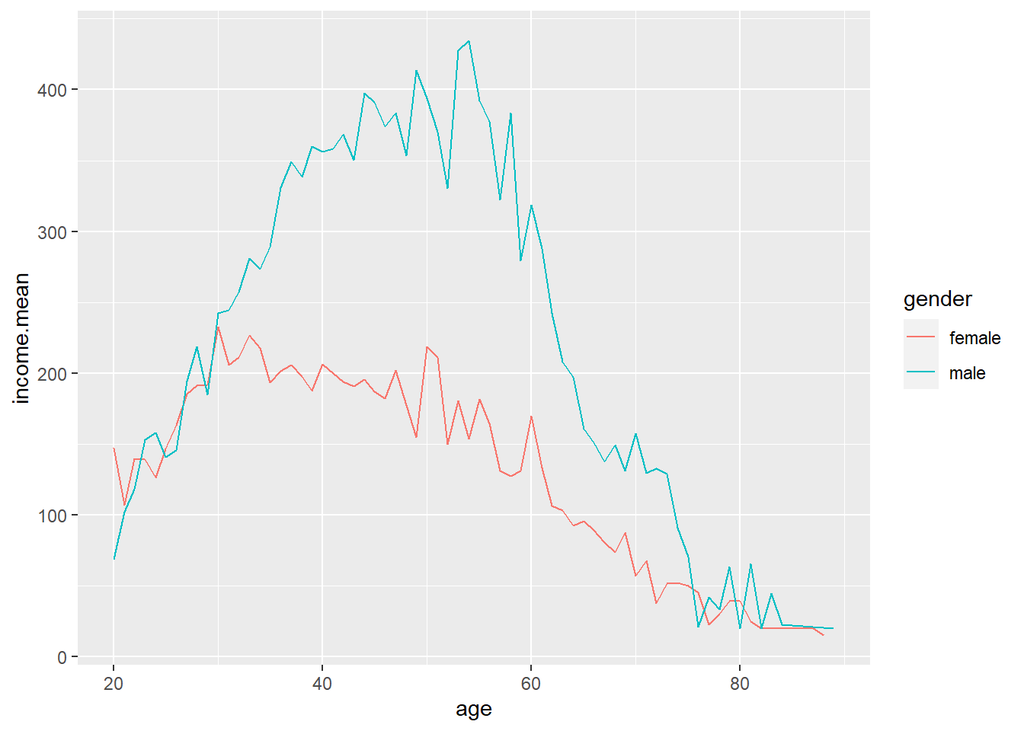

```r
ggplot(gender_age_income,aes(x=age,y=income.mean,col=gender))+
  geom_line()
```

```r
job_list<-read_excel("inData/inData/koweps/koweps_Codebook.xlsx",
                     col_names=T, sheet=2)
welfare<-left_join(welfare,job_list,id='code_job')
job_income<-welfare %>%
  filter(!is.na(welfare$income)) %>%
  group_by(job) %>%
  summarise(income.mean=mean(income),
            income.sd=sd(income),
            n=n()) %>%
  arrange(-income.mean) %>%
  head(10)
job_income
```

```
## # A tibble: 10 x 4
##    job                                  income.mean income.sd     n
##    <chr>                                      <dbl>     <dbl> <int>
##  1 금속 재료 공학 기술자 및 시험원             845.     874.      3
##  2 의료진료 전문가                             844.     591.      7
##  3 의회의원 고위공무원 및 공공단체임원         750      707.      2
##  4 보험 및 금융 관리자                         726.     301.     10
##  5 제관원 및 판금원                            572.      98.9     3
##  6 행정 및 경영지원 관리자                     564.     393.     12
##  7 문화 예술 디자인 및 영상 관련 관리자        557.     421.      3
##  8 연구 교육 및 법률 관련 관리자               550.     141.      8
##  9 건설 전기 및 생산 관련 관리자               536.     320.     27
## 10 석유 및 화학물 가공장치 조작원              532.     336.      5
```

### 7.2 상위 소득 10개 직업군 출력

```r
job_income<-welfare %>%
  filter(!is.na(welfare$income)) %>%
  group_by(job) %>%
  summarise(income.mean=mean(income),
            income.sd=sd(income),
            n=n()) %>%
  arrange(-income.mean) %>%
  head(10)
job_income
```

```
## # A tibble: 10 x 4
##    job                                  income.mean income.sd     n
##    <chr>                                      <dbl>     <dbl> <int>
##  1 금속 재료 공학 기술자 및 시험원             845.     874.      3
##  2 의료진료 전문가                             844.     591.      7
##  3 의회의원 고위공무원 및 공공단체임원         750      707.      2
##  4 보험 및 금융 관리자                         726.     301.     10
##  5 제관원 및 판금원                            572.      98.9     3
##  6 행정 및 경영지원 관리자                     564.     393.     12
##  7 문화 예술 디자인 및 영상 관련 관리자        557.     421.      3
##  8 연구 교육 및 법률 관련 관리자               550.     141.      8
##  9 건설 전기 및 생산 관련 관리자               536.     320.     27
## 10 석유 및 화학물 가공장치 조작원              532.     336.      5
```

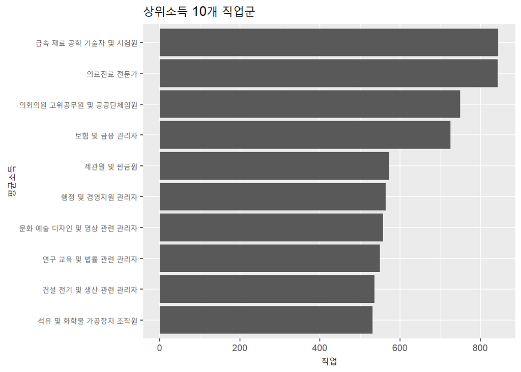

```r
ggplot(data=job_income,aes(x=income.mean,y=reorder(job,income.mean)))+
  geom_col()+
  labs(title='상위소득 10개 직업군',x='직업',y='평균소득')
```

```r
ggsave("outData/top10.png")
```

## 8. 성별 직업 빈도

### 8.1 여성 최빈 직업 top10

```r
job_female<-welfare %>%
  filter(!is.na(welfare$job)&gender=='female') %>%
  group_by(job) %>%
  summarise(cnt=n()) %>%
  arrange(desc(cnt)) %>%
  head(10)

job_female
```

```
## # A tibble: 10 x 2
##    job                            cnt
##    <chr>                        <int>
##  1 작물재배 종사자                680
##  2 청소원 및 환경 미화원          228
##  3 매장 판매 종사자               221
##  4 제조관련 단순 종사원           185
##  5 회계 및 경리 사무원            176
##  6 음식서비스 종사자              149
##  7 주방장 및 조리사               126
##  8 가사 및 육아 도우미            125
##  9 의료 복지 관련 서비스 종사자   121
## 10 음식관련 단순 종사원           104
```

```r
job_male<-welfare %>%
  filter(!is.na(welfare$job)&gender=='male') %>%
  group_by(job) %>%
  summarise(cnt=n()) %>%
  arrange(-cnt) %>%
  head(10)

job_male
```

```
## # A tibble: 10 x 2
##    job                        cnt
##    <chr>                    <int>
##  1 작물재배 종사자            640
##  2 자동차 운전원              251
##  3 경영관련 사무원            213
##  4 영업 종사자                141
##  5 매장 판매 종사자           132
##  6 제조관련 단순 종사원       104
##  7 청소원 및 환경 미화원       97
##  8 건설 및 광업 단순 종사원    95
##  9 경비원 및 검표원            95
## 10 행정 사무원                 92
```

## 9. 종교 유무에 따른 이혼율

### 9.1. 이상치 및 결측치 확인

```r
table(welfare$religion, useNA = "ifany")
```

```
##
##    1    2
## 8047 8617
```

```r
table(welfare$religion, exclude = NULL)
```

```
##
##    1    2
## 8047 8617
```

```r
table(is.na(welfare$religion))
```

```
##
## FALSE
## 16664
```

### 9.2. 1은 종교-유, 2는 종교-무로 데이터 변경

```r
welfare$religion <- ifelse(welfare$religion==1, '종교-유','종교-무')
```

### 9.3. 종교 유무의 빈도를 시각화

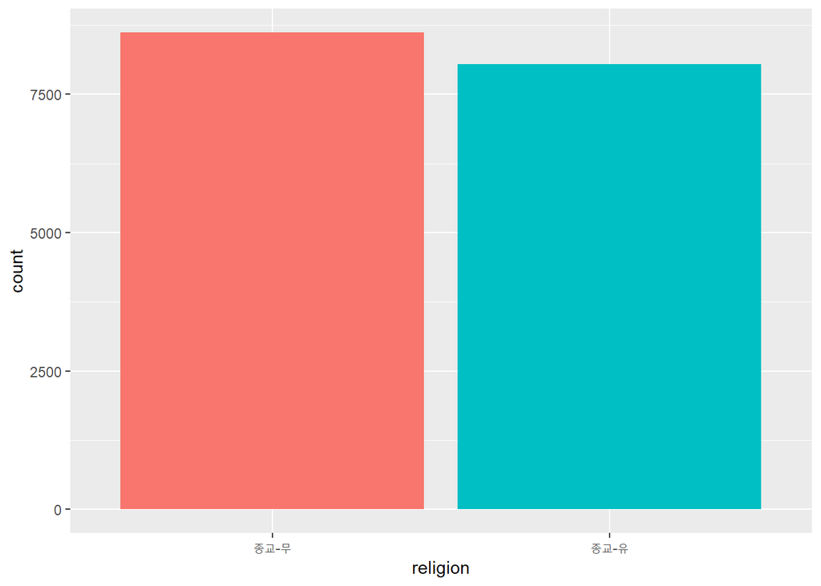

```r
ggplot(welfare, aes(x=religion,fill=religion)) +
  geom_bar()+
  theme(legend.position ="none")
```

### 9.4. 혼인 상태인 marriage에 따라, 파생변수 marriage_group 추가

```r
welfare <- welfare %>%
  mutate(marriage_group = ifelse(marriage ==1, "기혼",
                           ifelse(marriage ==3, "이혼",NA )))
```

### 9.5. 종교유무에 따른 이혼률 분석

```r
temp<-welfare %>%
  filter(!is.na(marriage_group)&!is.na(religion))
View(temp)
#도표..
table(temp$religion,temp$marriage_group)
```

```
##
##           기혼 이혼
##   종교-무 4218  384
##   종교-유 4213  328
```

```r
#시각화
religion_marriage<-welfare %>%
  filter(!is.na(marriage_group)) %>%
  group_by(religion,marriage_group) %>%
  summarise(n=n()) %>%
  mutate(tot_group=sum(n)) %>%
  mutate(pct=round(n/tot_group*100,1))
religion_marriage
```

```
## # A tibble: 4 x 5
## # Groups:   religion [2]
##   religion marriage_group     n tot_group   pct
##   <chr>    <chr>          <int>     <int> <dbl>
## 1 종교-무  기혼            4218      4602  91.7
## 2 종교-무  이혼             384      4602   8.3
## 3 종교-유  기혼            4213      4541  92.8
## 4 종교-유  이혼             328      4541   7.2
```

```r
var.test(data=temp,marriage~religion)
```

```
##
##  F test to compare two variances
##
## data:  marriage by religion
## F = 1.1413, num df = 4601, denom df = 4540, p-value = 8.064e-06
## alternative hypothesis: true ratio of variances is not equal to 1
## 95 percent confidence interval:
##  1.076945 1.209382
## sample estimates:
## ratio of variances
##           1.141251
```

```r
t.test(data=temp,marriage~religion,var.equal=F)
```

```
##
##  Welch Two Sample t-test
##
## data:  marriage by religion
## t = 2.0013, df = 9115.7, p-value = 0.04539
## alternative hypothesis: true difference in means is not equal to 0
## 95 percent confidence interval:
##  0.0004598197 0.0443849626
## sample estimates:
## mean in group 종교-무 mean in group 종교-유
##              1.166884              1.144462
```

### 9.6. 분석한 결과를 도표와 그래프로 시각화

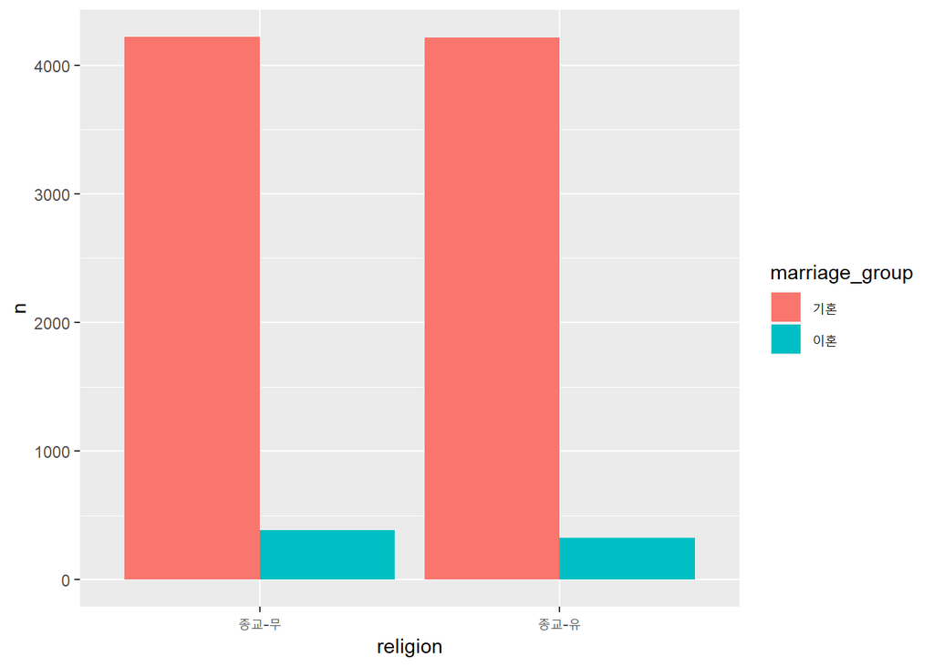

```r
ggplot(data=religion_marriage,aes(x=religion,y=n,fill=marriage_group))+
  geom_col(position='dodge')
```

## 10. 지역별 연령대 비율 ; 노년층이 많은 지역

### 10.1. 결측치 확인

```r
table(welfare$code_region,useNA='ifany')
```

```
##
##    1    2    3    4    5    6    7
## 2486 3711 2785 2036 1467 1257 2922
```

```r
table(!is.na(welfare$agegrade))
```

```
##
##  TRUE
## 16664
```

```r
table(!is.na(welfare$code_region))
```

```
##
##  TRUE
## 16664
```

### 10.2. region파생변수 추가

```r
region_list <- data.frame(code_region = c(1:7),
                          region=c('서울',
                                   '수도권(인천/경기)',
                                   '부산/경남/울산',
                                   '대구/경북',
                                   '대전/충남',
                                   '강원/충북',
                                   '광주/전남/전북/제주도'))
welfare <- left_join(welfare, region_list, by="code_region")
```

### 10.3. 지역별 연령대 비율을 분석한 도표 및 그래프

```r
region_agegrade<-welfare %>%
  group_by(region, agegrade) %>%
  summarise(n = n()) %>%
  mutate(tot_group = sum(n)) %>%
  mutate(pct = round(n/tot_group*100, 2))
```

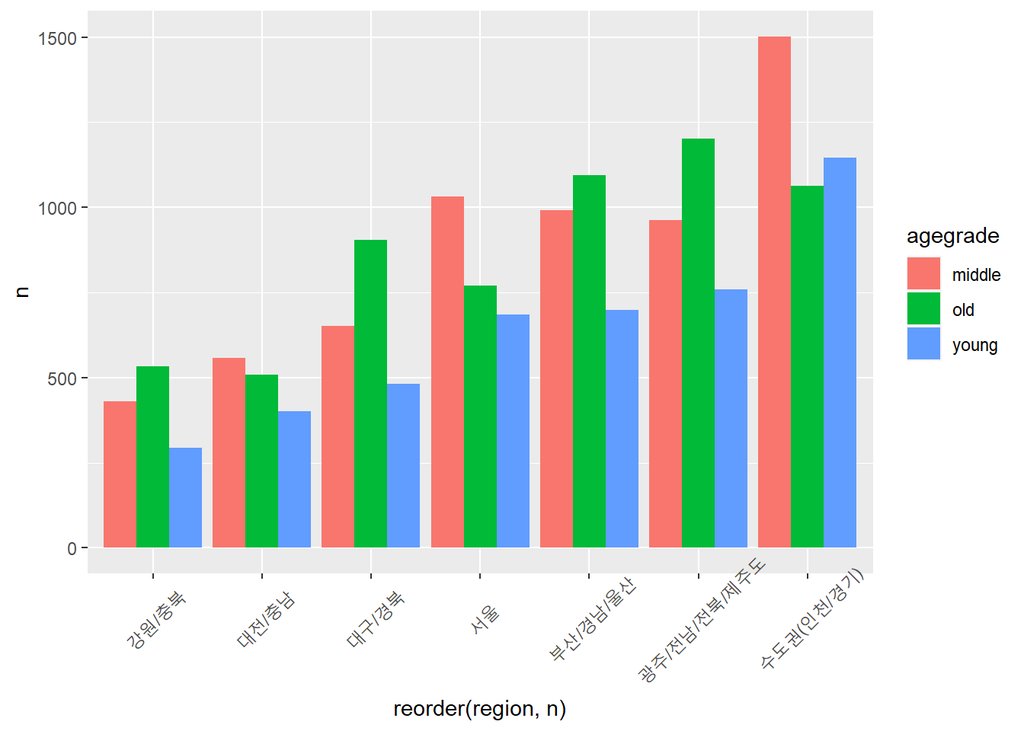

```r
ggplot(data=region_agegrade, aes(x=reorder(region, n), y=n, fill=agegrade)) +
  geom_col(position = 'dodge') +
  theme(axis.text.x = element_text(angle = 45, vjust=0.7))
```

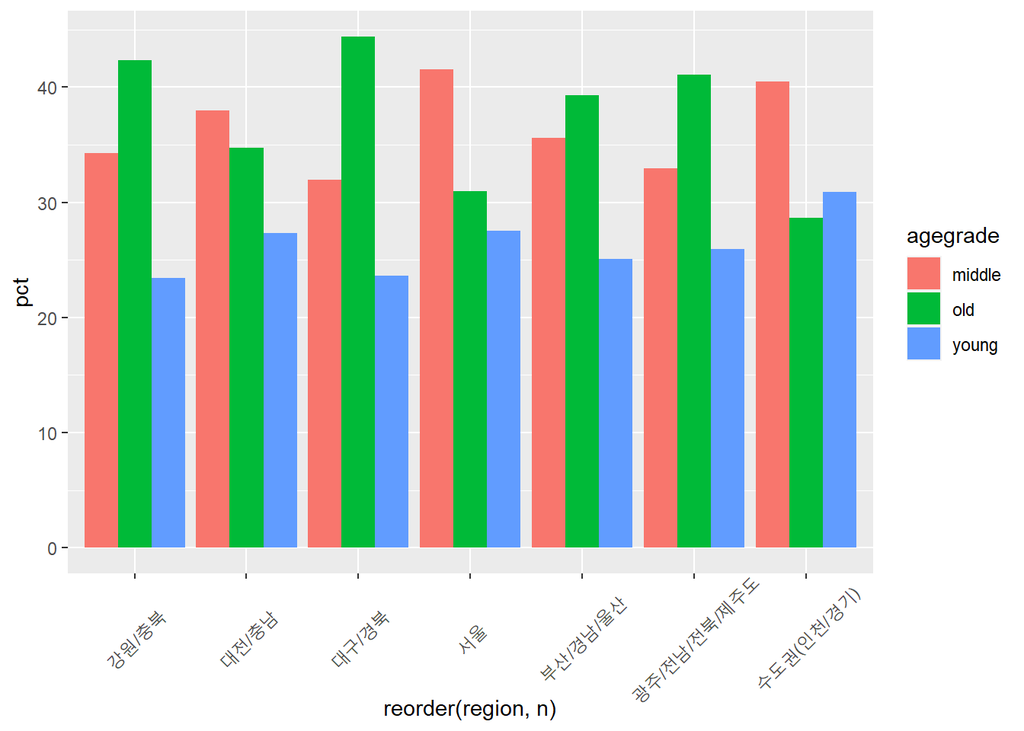

```r
# 지역별 연령대 비율
ggplot(data=region_agegrade, aes(x=reorder(region, n), y=pct, fill=agegrade)) +
  geom_col(position = 'dodge') +
  theme(axis.text.x = element_text(angle=45, vjust=0.5))
```

### 10.4. 노년층이 많은 지역

```r
oldagegrade_region <- region_agegrade %>%
  filter(agegrade=='old') %>%
  arrange(desc(pct))
oldagegrade_region
```

```
## # A tibble: 7 x 5
## # Groups:   region [7]
##   region                agegrade     n tot_group   pct
##   <chr>                 <chr>    <int>     <int> <dbl>
## 1 대구/경북             old        904      2036  44.4
## 2 강원/충북             old        532      1257  42.3
## 3 광주/전남/전북/제주도 old       1201      2922  41.1
## 4 부산/경남/울산        old       1094      2785  39.3
## 5 대전/충남             old        509      1467  34.7
## 6 서울                  old        769      2486  30.9
## 7 수도권(인천/경기)     old       1063      3711  28.6
```

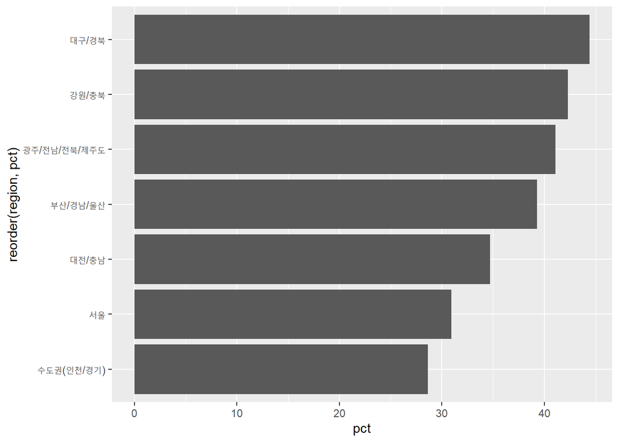

```r
ggplot(data=oldagegrade_region,
       aes(x = pct, y=reorder(region, pct))) +geom_col()
```